# Multi-Model LLM Benchmark Report

MTC Structured Extraction — Visual Model Comparison

Published

March 17, 2026

# 1 Overview

This report compares all benchmarked language models on **Mill Test Certificate (MTC) structured extraction** accuracy. Four models have confirmed results via GitHub Models; Qwen2.5 models are available via the HuggingFace Inference API.

Models are scored against a human-annotated ground truth on five dimensions:

| Dimension | Metric |
| --- | --- |
| Document fields | Exact-match accuracy (5 fields) |
| Chemical composition | Heat-number F1 + per-element accuracy |
| Mechanical properties | Row F1 + per-property accuracy |
| Approval | Exact-match accuracy |
| **Overall** | Weighted mean of all component F1s |

```
Summary has 6 model entries.
Ground truth loaded: True
```

```
Successful models: 6
Failed models:     0
```

# 2 Model Registry

Table 1: Successful models — benchmark summary

| Model | Latency (s) | Total Tokens | Est. Cost ($) | Doc Acc | Chem F1 | Mech F1 | Overall F1 |
| --- | --- | --- | --- | --- | --- | --- | --- |
| gpt-4o | 0.0s | 0 | 0.000000 | 100.0% | 100.0% | 100.0% | 100.0% |
| Meta-Llama-3.1-405B-Instruct | 0.0s | 0 | 0.000000 | 100.0% | 100.0% | 92.6% | 90.5% |
| Meta-Llama-3.1-8B-Instruct | 0.0s | 0 | 0.000000 | 100.0% | 100.0% | 65.8% | 84.9% |
| gpt-4o-mini | 0.0s | 0 | 0.000000 | 100.0% | 100.0% | 94.0% | 90.6% |
| Qwen2.5-7B-Instruct | 0.0s | 0 | 0.000000 | 100.0% | 100.0% | 87.8% | 84.9% |
| Llama-3.1-8B-Instruct | 0.0s | 0 | 0.000000 | 100.0% | 100.0% | 48.0% | 80.0% |

# 3 Grouped Bar Chart — Quality per Section

Each cluster of bars represents one model; bar colour encodes the metric dimension.

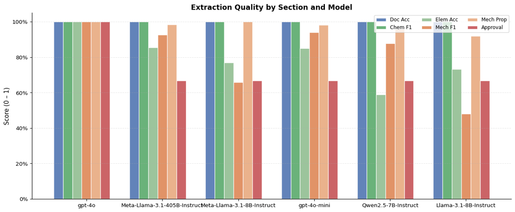

Section-level accuracy / F1 grouped by model.

# 4 Radar / Spider Chart — Overall Quality Profile

Each polygon represents one model across five quality axes.

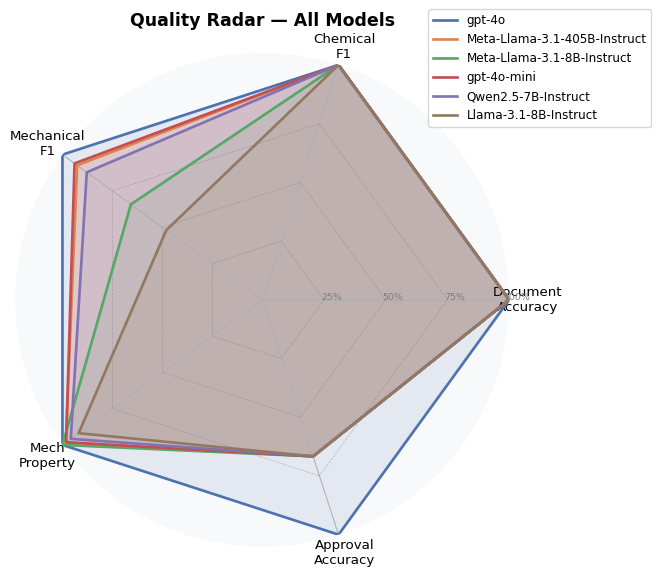

Overall quality radar chart — one polygon per model.

# 5 Latency vs Quality Scatter

Bubble size = total token usage. Models in the upper-left corner offer the best quality-per-second trade-off.

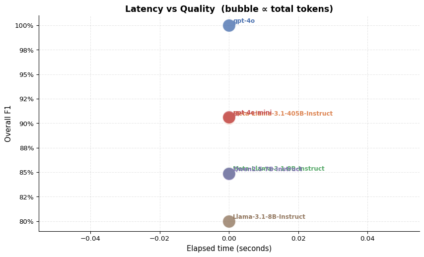

Latency vs overall F1 — bubble area proportional to total tokens used.

# 6 Token Usage & Estimated Cost

Stacked bars show prompt (left) and completion (right) token usage. Estimated costs use public API pricing — GitHub Models and HuggingFace serverless inference are **free** in Codespaces / on free tier (shown as $0.00).

[figure not shown]

Token usage (stacked) and estimated API cost per model.

# 7 Per-Field Accuracy Heatmap

Rows = models; columns = individual metrics. Colour intensity shows accuracy (0 = red, 1 = green).

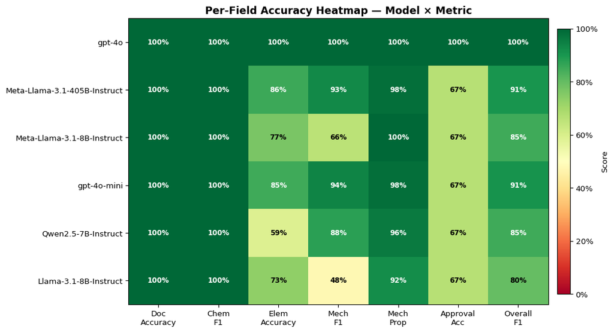

Per-section accuracy heatmap — each cell is one metric for one model.

## 7.1 Document Field Detail

Per-field exact-match results for each successful model.

Table 2: Document field exact-match per model (✓ = correct, ✗ = wrong, — = unevaluated)

| Field Model | certificate_number | customer | issuing_date | order_number | standard |
| --- | --- | --- | --- | --- | --- |
| Llama-3.1-8B-Instruct | ✓ | ✓ | ✓ | ✓ | ✓ |
| Meta-Llama-3.1-405B-Instruct | ✓ | ✓ | ✓ | ✓ | ✓ |
| Meta-Llama-3.1-8B-Instruct | ✓ | ✓ | ✓ | ✓ | ✓ |
| Qwen2.5-7B-Instruct | ✓ | ✓ | ✓ | ✓ | ✓ |
| gpt-4o | ✓ | ✓ | ✓ | ✓ | ✓ |
| gpt-4o-mini | ✓ | ✓ | ✓ | ✓ | ✓ |

# 8 Error / Failure Breakdown

Models that failed during the benchmark run (endpoint unavailable, unknown model ID, etc.).

```
No failures recorded.
```

# 9 How to Add New Models

## 9.1 HuggingFace Models (Qwen2.5, etc.)

1. **Get a HuggingFace token:** https://huggingface.co/settings/tokens (free account, read access is sufficient for serverless inference).
2. **Set the env var:** `export HF_TOKEN=hf_...` or add it as a Codespace secret.
3. **Run** with the HF provider flag:

```bash
# Qwen2.5-72B only, with ground-truth evaluation, 1 s sleep between pages
python src/extraction/llm_models_extraction.py \
    --use-cached-ocr \
    --models "Qwen/Qwen2.5-72B-Instruct" \
    --ground-truth data/ground_truth/diler-07-07-2025-rerun-41-44_gt.json \
    --rate-limit-sleep 1.0
```

4. **Render this report** after the run to see the new model appear in every chart:

```bash
quarto render benchmark_report.qmd
```

## 9.2 GitHub Models (new model IDs)

Add an entry to `RANKED_MODELS` in `src/extraction/llm_models_extraction.py` with the correct `id`, `label`, `provider`, `tier`, `base_url` (`https://models.inference.ai.azure.com`), and `api_key_env` (`GITHUB_TOKEN`). Then run as normal.

*Report generated with [Quarto](https://quarto.org). Evaluation logic: `src/evaluation/evaluator.py`.*